# Interlaboratory comparison

## Load estimation results

The first step is to select how many laboratories are going to participate in the comparison and upload their corresponding Estimation results file. Those files must be in `.rds` format obtained in the dose estimation module in Biodose Tools. Clicking on “Dose estimation summary” will load the files into the app and display the contained information on the “Results” tabbed box in four different tables: (1) Data summary, with total number of cells ($N$), total number of aberrations ($X$), mean ($\bar{y}$), standard error ($\sigma$), dispersion index ($\sigma^{2}/\bar{y}$), and $u$-value, as well as the dose estimation with the upper and lower limits, the ($Sample$) name identifying each case with their corresponding ID, the ($Module$), the ($Lab$) and the ($Type$) of method used for the scoring of the curve used for the estimation. (2) Curves, with the ($Module$), the ($Lab$) and the ($Type$) as well as the used curve coefficients, standard errors ($\sigma$) and several irradiation conditions. Tables (3) and (4) will display for each Lab ans Sample the dose estimation for “Dose” and the Frequencies for “Frequencies”.

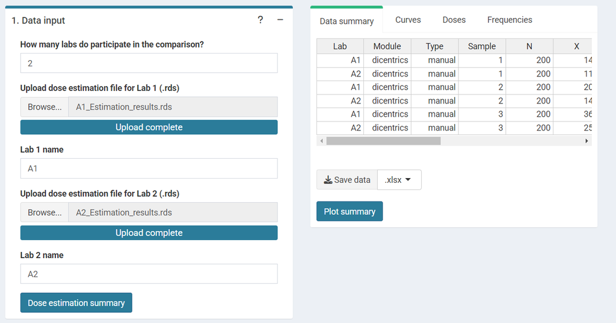

‘Data Input’ box and ‘Results’ tabbed box in the interlaboratory comparison module when loading curves from an `.rds` file for two laboratories.

This step is accomplished in R by loading an existing `.rds` object via `readRDS()`:

```r
fit_results_A1 <- system.file("extdata", "A1_Estimation_results.rds",
    package = "biodosetools") %>%
    readRDS()

fit_results_A2 <- system.file("extdata", "A2_Estimation_results.rds",
    package = "biodosetools") %>%
    readRDS()
```

And then calling ’summary_curve_tables()`:

```r
list_lab_names <- list("A1", "A2")
all_rds <- list(fit_results_A1, fit_results_A2)

tables_list <- summary_curve_tables(
  num_labs = 2,
  list_lab_names,
  all_rds
)
```

## Plot data input

Clicking on “Plot summary” will display four different plots in the “Plots summary” Results tabbox.

This step is accomplished in R by calling: `yield_boxplot()`, `dose_boxplot()`, `u_test_plot()` and `DI_plot()` functions:

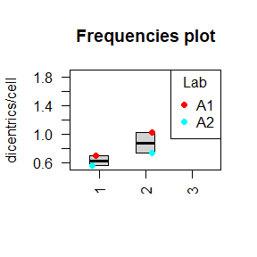

```r
yield_boxplot(
  dat =  tables_list[[1]],
  place = "UI"
)
```

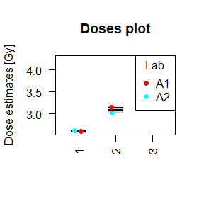

```r
dose_boxplot(
  dat = tables_list[[1]],
  place = "UI"
)
```

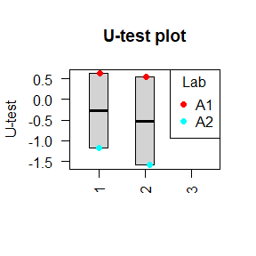

```r
u_test_plot(
  dat = tables_list[[1]],
  place = "UI"
)
```

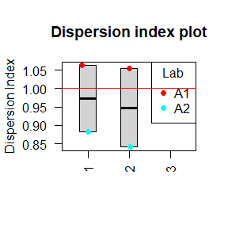

```r
DI_plot(
  dat = tables_list[[1]],
  place = "UI"
)
```

Clicking on “Plot curves” on the Curve section on the Results tabbox will display four different plots in the “Plots curves” Results tabbox.In this example all curves were manually scored, therefore there are only two plots.

This step is accomplished in R by calling: `curves_plot()`and `bar_plots()` functions:

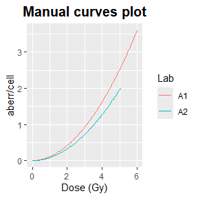

```r
curves_plot(
  dat = tables_list[[2]],
  curve = "manual",
  curve_type = "lin_quad",
  place = "UI"
)
```

[figure not shown]

```r
bar_plots(
  dat = tables_list[[2]],
  curve = "manual",
  place = "UI"
)
```

## Performe Z-score

The final step is to select the Input type between “Dose” or “Frequency”, the algorithm among “AlgA”, “AlgB and”QHampel” and provide the reference value for each sample (only when Dose input is selected).

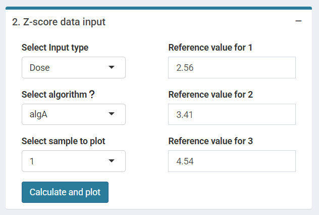

‘Z-score Data input options’ in the interlaboratory comparison module.

Clicking “Calculate and plot” will display the results table:

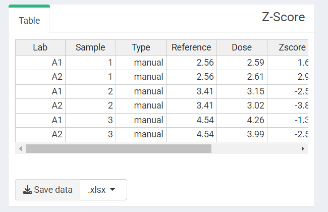

‘Z-score Results table’ in the interlaboratory comparison module.

To calculate the Z-Score in R we can call `calc.zValue.new()`:

```r
zscore_S1 <- calc.zValue.new(
  X =  tables_list[[1]][["estimate"]][1:2],
  type = "dose",
  alg = "algA",
  c = 2.56
)

zscore_S2 <- calc.zValue.new(
  X =  tables_list[[1]][["estimate"]][3:4],
  type = "dose",
  alg = "algA",
  c = 3.41
)

zscore_S3 <- calc.zValue.new(
  X =  tables_list[[1]][["estimate"]][5:6],
  type = "dose",
  alg = "algA",
  c = 4.54
)
```

We can generate the plots in R by calling: `plot_zscore_all()`, `plot_deviation_all`, `plot_interlab_v2()`, `plot_interlab_deviation()` and `plot_triage_interlab()` functions:

```r
data_frame_zscore <- data.frame(
          Lab = tables_list[[1]][["Lab"]],
          Sample = tables_list[[1]][["Sample"]],
          Type = tables_list[[1]][["Type"]],
          Reference = c(2.56, 3.41, 4.54),
          Dose = tables_list[[1]][["estimate"]],
          Deviation = tables_list[[1]][["estimate"]] - c(2.56, 3.41, 4.54),
          Zscore = c(zscore_S1, zscore_S2, zscore_S3),
          stringsAsFactors = FALSE
        )

plot_1 <- plot_zscore_all(
  zscore = data_frame_zscore,
  select_method = "algA",
  place = "UI"
)

plot_2 <- plot_deviation_all(
  zscore = data_frame_zscore,
  select_method = "algA",
  place = "UI"
)

plot_3 <- plot_interlab_v2(
  zscore = data_frame_zscore,
  select_method = "algA",
  sum_table = tables_list[[1]],
  place = "UI"
)


plot_4 <- plot_interlab_deviation(
  zscore = data_frame_zscore,
  sum_table = tables_list[[1]],
  place = "UI"
)


line_triage <- list(`1` = 2.56, `2` = 3.41, `3` = 4.54)

plot_5 <- plot_triage_interlab(
  line_triage,
  sum_table = tables_list[[1]],
  place = "UI"
)
```

`plot_interlab_v2()`, `plot_interlab_deviation()` and `plot_triage_interlab()` functions generate a list of plots (1 for each sample).

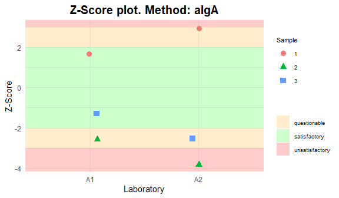

Plots generated by {biodosetools}.

```r
plot_1
```

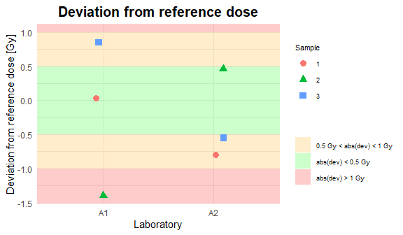

Plots generated by {biodosetools}.

```r
plot_2
```

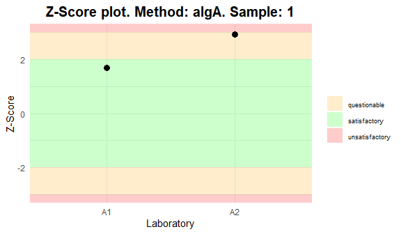

Plots generated by {biodosetools}.

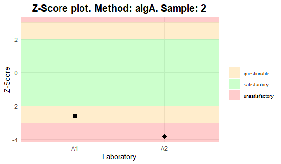

Plots generated by {biodosetools}.

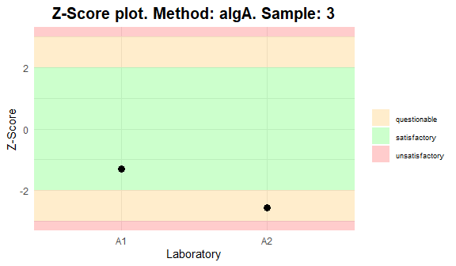

Plots generated by {biodosetools}.

```r
for (p in plot_3) print(p)
```

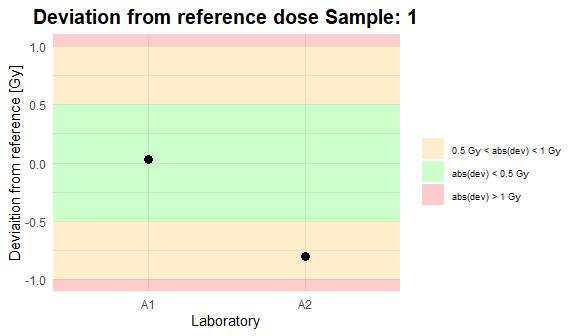

Plots generated by {biodosetools}.

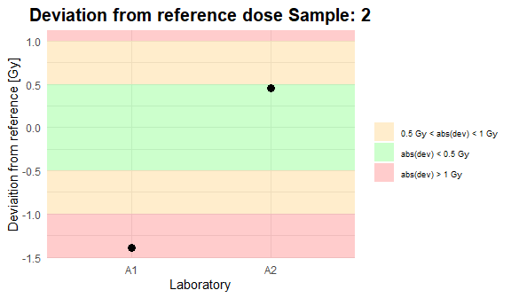

Plots generated by {biodosetools}.

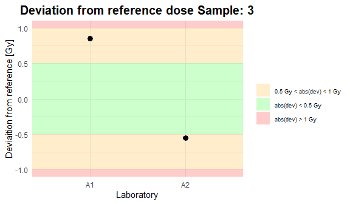

Plots generated by {biodosetools}.

```r
for (p in plot_4) print(p)
```

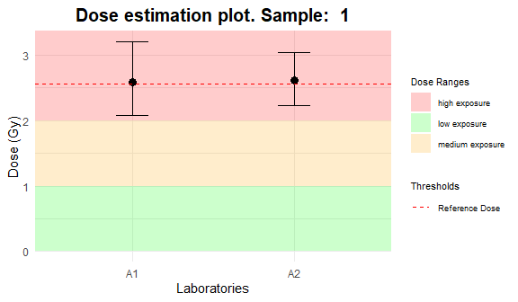

Plots generated by {biodosetools}.

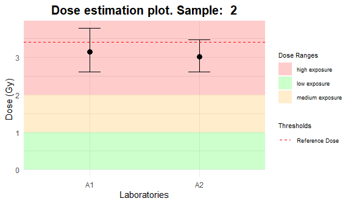

Plots generated by {biodosetools}.

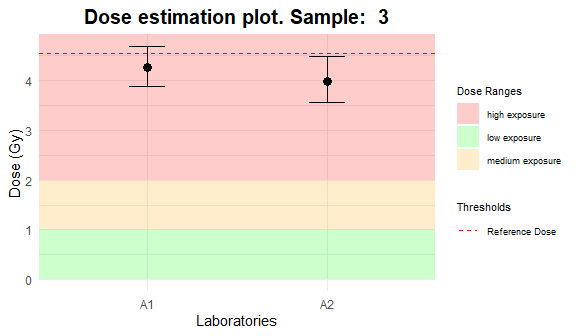

Plots generated by {biodosetools}.

```r
for (p in plot_5) print(p)
```